# Projet 1 : Base Alimentaire

Balkis Benslimene

# 1. Introduction

Le jeu de données intitulé « Base Alimentaire » présente les dépenses annuelles moyennes de consommation de 12 individus sur différents produits alimentaires. Chaque individu est identifié par un code (IDEN).

Ce projet s’inscrit dans le cadre de l’exploration et de l’analyse de données de consommation alimentaire à l’aide de techniques de data mining, notamment l’Analyse en Composantes Principales (ACP). Les variables étudiées incluent : pain, légumes, fruits, viande, volaille, lait, vin, la catégorie socio-professionnelle (CSP) et le nombre d’enfants à charge.

### Objectifs de l’étude :

- Identifier des structures latentes dans les habitudes de consommation.
- Réduire la dimensionnalité des données tout en conservant l’essentiel de l’information.
- Visualiser la répartition des individus selon leurs profils alimentaires.
- Identifier les facteurs principaux influençant les dépenses.

# 2. Chargement et Structure des Données

```r
knitr::opts_chunk$set(root.dir = "C:/Users/balkis/Desktop/data minig/")
```

```r
install.packages("readxl")  # qui est installer dans mon cas
library(readxl)
df <- read_excel("Base alimentaire.xls")
head(df)
```

| IDEN | pain | légumes | fruits | viande | volaille | lait | vin | CSP | enfants |
| --- | --- | --- | --- | --- | --- | --- | --- | --- | --- |
| MA2 | 332 | 428 | 354 | 1437 | 526 | 247 | 427 | 1 | 2 |
| EM2 | 293 | 559 | 388 | 1527 | 567 | 239 | 258 | 2 | 2 |
| CA2 | 372 | 767 | 562 | 1948 | 927 | 235 | 433 | 3 | 2 |
| MA3 | 406 | 563 | 341 | 1507 | 544 | 324 | 407 | 1 | 3 |
| EM3 | 386 | 608 | 396 | 1501 | 568 | 319 | 363 | 2 | 3 |
| CA3 | 438 | 843 | 689 | 2345 | 1148 | 243 | 341 | 3 | 3 |

```r
NA
NA
```

### on va créer un tableau interactif

|  | IDEN | pain | légumes | fruits | viande | volaille | lait | vin | CSP | enfants |
| --- | --- | --- | --- | --- | --- | --- | --- | --- | --- | --- |
| 1 | MA2 | 332 | 428 | 354 | 1437 | 526 | 247 | 427 | 1 | 2 |
| 2 | EM2 | 293 | 559 | 388 | 1527 | 567 | 239 | 258 | 2 | 2 |
| 3 | CA2 | 372 | 767 | 562 | 1948 | 927 | 235 | 433 | 3 | 2 |
| 4 | MA3 | 406 | 563 | 341 | 1507 | 544 | 324 | 407 | 1 | 3 |
| 5 | EM3 | 386 | 608 | 396 | 1501 | 568 | 319 | 363 | 2 | 3 |
| 6 | CA3 | 438 | 843 | 689 | 2345 | 1148 | 243 | 341 | 3 | 3 |
| 7 | MA4 | 534 | 660 | 367 | 1620 | 638 | 414 | 407 | 1 | 4 |
| 8 | EM4 | 460 | 699 | 484 | 1856 | 762 | 400 | 416 | 2 | 4 |
| 9 | CA4 | 385 | 789 | 621 | 2366 | 1149 | 304 | 282 | 3 | 4 |
| 10 | MA5 | 655 | 776 | 423 | 1848 | 759 | 495 | 486 | 1 | 5 |

[output cut: 2 more lines]

### Structure du dataset

La fonction str() nous montrera la structure des données, c’est-à-dire le nombre de lignes et colonnes, les types de chaque variable (numérique, facteur, etc.), et quelques valeurs des premières observations.

```r
str(df)
```

```
tibble [12 × 10] (S3: tbl_df/tbl/data.frame)
 $ IDEN    : chr [1:12] "MA2" "EM2" "CA2" "MA3" ...
 $ pain    : num [1:12] 332 293 372 406 386 438 534 460 385 655 ...
 $ légumes : num [1:12] 428 559 767 563 608 843 660 699 789 776 ...
 $ fruits  : num [1:12] 354 388 562 341 396 689 367 484 621 423 ...
 $ viande  : num [1:12] 1437 1527 1948 1507 1501 ...
 $ volaille: num [1:12] 526 567 927 544 568 ...
 $ lait    : num [1:12] 247 239 235 324 319 243 414 400 304 495 ...
 $ vin     : num [1:12] 427 258 433 407 363 341 407 416 282 486 ...
 $ CSP     : num [1:12] 1 2 3 1 2 3 1 2 3 1 ...
 $ enfants : num [1:12] 2 2 2 3 3 3 4 4 4 5 ...
```

- 12 observations et 10 variables.
- IDEN est de type caractère → variable supplémentaire (non utilisée dans l’ACP).
- Les autres variables sont numériques, dont CSP et enfants à considérer comme catégorielles.

# 3. Analyse univariée

## Dimensions du dataset

Connaître le nombre de lignes et de colonnes est essentiel pour avoir une vue d’ensemble de la taille du dataset.

```r
dimensions <-dim(df)
n_lignes <- dimensions[1]
n_colonnes <- dimensions[2]
message <- paste("Notre data est composées de " , n_colonnes, "colonnes et",  n_lignes,  "lignes " )
message
```

```
[1] "Notre data est composées de  10 colonnes et 12 lignes "
```

## Type des variables

Indiquer les types de chaque variable (numérique, catégorique, etc.) peut fournir des informations utiles sur la manière dont les données doivent être analysées.

```r
types_variables <- sapply(df, class)
types_variables
```

```
       IDEN        pain     légumes      fruits      viande    volaille        lait         vin         CSP     enfants
"character"   "numeric"   "numeric"   "numeric"   "numeric"   "numeric"   "numeric"   "numeric"   "numeric"   "numeric"
```

- Majoritairement numériques.

## Résumé statistique des variables numériques :

Présente un résumé des variables numériques, notamment les statistiques descriptives (moyenne, médiane, écart-type, minimum, maximum, etc.). Cela permet de mieux comprendre la distribution des données.

```r
summary(df)
```

```
     IDEN                pain          légumes           fruits          viande        volaille           lait            vin             CSP
 Length:12          Min.   :293.0   Min.   : 428.0   Min.   :341.0   Min.   :1437   Min.   : 526.0   Min.   :235.0   Min.   :258.0   Min.   :1
 Class :character   1st Qu.:381.8   1st Qu.: 596.8   1st Qu.:382.8   1st Qu.:1522   1st Qu.: 567.8   1st Qu.:246.0   1st Qu.:310.2   1st Qu.:1
 Mode  :character   Median :422.0   Median : 733.0   Median :453.5   Median :1852   Median : 760.5   Median :321.5   Median :385.0   Median :2
                    Mean   :446.7   Mean   : 732.0   Mean   :505.0   Mean   :1887   Mean   : 804.0   Mean   :358.2   Mean   :368.6   Mean   :2
                    3rd Qu.:519.8   3rd Qu.: 802.5   3rd Qu.:576.8   3rd Qu.:2128   3rd Qu.: 982.2   3rd Qu.:434.2   3rd Qu.:418.8   3rd Qu.:3
                    Max.   :655.0   Max.   :1097.0   Max.   :887.0   Max.   :2630   Max.   :1167.0   Max.   :561.0   Max.   :486.0   Max.   :3
    enfants
 Min.   :2.00
 1st Qu.:2.75
 Median :3.50
 Mean   :3.50
 3rd Qu.:4.25
 Max.   :5.00
```

- Variables comme viande et volaille présentent une forte dispersion.
- CSP varie entre (1 = manœuvre, 2 = employé et 3 = cadre)
- Nombre d’enfants de 2 à 5.

# 4. Prétraitement des données

## Séparer les variables quantitatives

```r
library(dplyr)

donnees_quant <- df %>% select(pain, légumes, fruits, viande, volaille, lait, vin)
```

Permet de visualiser les corrélations fortes (par ex. fruits , viande et volaille).

## Normalisation des données

```r
donnees_norm <- scale(donnees_quant)
donnees_norm
```

```
             pain    légumes     fruits      viande   volaille       lait        vin
 [1,] -1.07017495 -1.6069348 -0.9146401 -1.13644860 -1.1178903 -0.9498231  0.8138087
 [2,] -1.43415887 -0.9144728 -0.7086946 -0.90903254 -0.9530216 -1.0181250 -1.5405481
 [3,] -0.69685811  0.1850089  0.3452615  0.15476927  0.4946062 -1.0522760  0.8973954
 [4,] -0.37953879 -0.8933289 -0.9933839 -0.95956944 -1.0455089 -0.2924175  0.5351866
 [5,] -0.56619721 -0.6554602 -0.6602369 -0.97473051 -0.9490004 -0.3351061 -0.0777820
 [6,] -0.08088532  0.5867426  1.1145283  1.15792679  1.3832888 -0.9839741 -0.3842663
 [7,]  0.81507511 -0.3805898 -0.8358962 -0.67403594 -0.6675173  0.4759788  0.5351866
 [8,]  0.12443895 -0.1744370 -0.1272016 -0.07770049 -0.1688899  0.3564505  0.6605666
 [9,] -0.57553013  0.3013003  0.7026374  1.21099054  1.3873100 -0.4631722 -1.2062015
[10,]  1.94435855  0.2325827 -0.4966920 -0.09791525 -0.1809535  1.1675354  1.6357439
[11,]  1.28172116  1.3902100  0.2604604  0.42766854  0.3578858  1.3639033 -0.6907506
[12,]  0.63774961  1.9293789  2.3138577  1.87807765  1.4596913  1.7310260 -1.1783393
attr(,"scaled:center")
     pain   légumes    fruits    viande  volaille      lait       vin
 446.6667  732.0000  505.0000 1886.7500  804.0000  358.2500  368.5833
attr(,"scaled:scale")
     pain   légumes    fruits    viande  volaille      lait       vin
107.14759 189.18005 165.09226 395.75041 248.68271 117.12707  71.78181
```

## Calculer les corrélations : corrélogramme

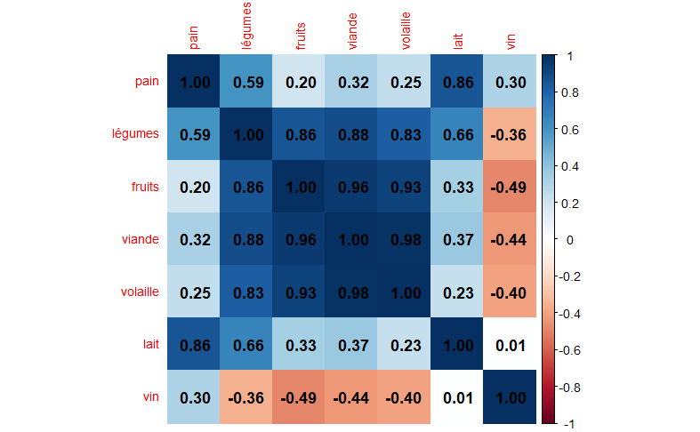

```r
library(corrplot)
cor_matrix <- cor(donnees_norm)
corrplot(cor_matrix, method = "color", addCoef.col = "black", tl.cex = 0.8)
```

### correlartion Négative

- il ya moyenne corelation négative entre vin et (légumes , fruits , viandes et volailles) .

## Garder les variables qualitatives à part

```r
csp <- as.factor(df$CSP)
```

# 5. Analyse en Composantes Principales (ACP)

## Normaliser les données - Réalisation de l’ACP

```r
summary(res_pca)
```

```
Call:
PCA(X = df, quanti.sup = "enfants", quali.sup = c("IDEN", "CSP"),
     graph = FALSE)


Eigenvalues
                       Dim.1   Dim.2   Dim.3   Dim.4   Dim.5   Dim.6   Dim.7
Variance               4.334   1.831   0.630   0.128   0.057   0.019   0.001
% of var.             61.910  26.158   9.001   1.829   0.819   0.268   0.015
Cumulative % of var.  61.910  88.068  97.069  98.898  99.717  99.985 100.000

Individuals (the 10 first)
             Dist    Dim.1    ctr   cos2    Dim.2    ctr   cos2    Dim.3    ctr   cos2
1        |  3.075 | -2.989 17.180  0.945 | -0.379  0.655  0.015 |  0.419  2.320  0.019 |
2        |  3.052 | -1.976  7.504  0.419 | -1.871 15.928  0.376 | -1.367 24.733  0.201 |
3        |  1.754 | -0.124  0.029  0.005 | -0.758  2.615  0.187 |  1.484 29.145  0.716 |
4        |  2.170 | -2.135  8.764  0.968 |  0.338  0.521  0.024 | -0.113  0.170  0.003 |
5        |  1.855 | -1.754  5.918  0.894 | -0.177  0.143  0.009 | -0.523  3.621  0.080 |
6        |  2.551 |  1.771  6.030  0.482 | -1.415  9.115  0.308 |  1.039 14.284  0.166 |
7        |  1.785 | -0.977  1.837  0.300 |  1.434  9.352  0.645 | -0.290  1.112  0.026 |
8        |  0.849 | -0.265  0.135  0.098 |  0.661  1.990  0.607 |  0.284  1.070  0.112 |
9        |  2.553 |  1.673  5.382  0.429 | -1.813 14.963  0.504 |  0.102  0.137  0.002 |
10       |  2.984 |  0.228  0.100  0.006 |  2.901 38.299  0.945 |  0.592  4.630  0.039 |

Variables
            Dim.1    ctr   cos2    Dim.2    ctr   cos2    Dim.3    ctr   cos2
pain     |  0.498  5.728  0.248 |  0.842 38.710  0.709 | -0.009  0.012  0.000 |
légumes  |  0.970 21.701  0.940 |  0.134  0.974  0.018 | -0.049  0.379  0.002 |
fruits   |  0.929 19.929  0.864 | -0.277  4.204  0.077 |  0.116  2.137  0.013 |
viande   |  0.962 21.357  0.926 | -0.191  1.982  0.036 |  0.165  4.309  0.027 |
volaille |  0.912 19.172  0.831 | -0.267  3.887  0.071 |  0.281 12.571  0.079 |
lait     |  0.584  7.872  0.341 |  0.707 27.317  0.500 | -0.352 19.671  0.124 |
vin      | -0.429  4.241  0.184 |  0.648 22.925  0.420 |  0.620 60.922  0.384 |

Supplementary continuous variable
            Dim.1   cos2    Dim.2   cos2    Dim.3   cos2
enfants  |  0.683  0.466 |  0.620  0.384 | -0.236  0.056 |

Supplementary categories (the 10 first)
             Dist    Dim.1   cos2 v.test    Dim.2   cos2 v.test    Dim.3   cos2 v.test
CA2      |  1.754 | -0.124  0.005 -0.059 | -0.758  0.187 -0.560 |  1.484  0.716  1.870 |
CA3      |  2.551 |  1.771  0.482  0.851 | -1.415  0.308 -1.046 |  1.039  0.166  1.309 |
CA4      |  2.553 |  1.673  0.429  0.804 | -1.813  0.504 -1.340 |  0.102  0.002  0.128 |
CA5      |  4.615 |  4.512  0.956  2.167 | -0.103  0.001 -0.076 | -0.593  0.016 -0.747 |
EM2      |  3.052 | -1.976  0.419 -0.949 | -1.871  0.376 -1.383 | -1.367  0.201 -1.723 |
EM3      |  1.855 | -1.754  0.894 -0.843 | -0.177  0.009 -0.131 | -0.523  0.080 -0.659 |
EM4      |  0.849 | -0.265  0.098 -0.128 |  0.661  0.607  0.489 |  0.284  0.112  0.358 |
EM5      |  2.620 |  2.037  0.604  0.978 |  1.183  0.204  0.874 | -1.034  0.156 -1.302 |
MA2      |  3.075 | -2.989  0.945 -1.436 | -0.379  0.015 -0.280 |  0.419  0.019  0.528 |
MA3      |  2.170 | -2.135  0.968 -1.025 |  0.338  0.024  0.250 | -0.113  0.003 -0.143 |
```

## Valeurs propres (inertie)

```r
res_pca$eig
```

```
        eigenvalue percentage of variance cumulative percentage of variance
comp 1 4.333701367            61.91001952                          61.91002
comp 2 1.831028876            26.15755537                          88.06757
comp 3 0.630082937             9.00118481                          97.06876
comp 4 0.128063246             1.82947495                          98.89823
comp 5 0.057296696             0.81852422                          99.71676
comp 6 0.018743326             0.26776180                          99.98452
comp 7 0.001083553             0.01547932                         100.00000
```

## Graphe des valeurs propres

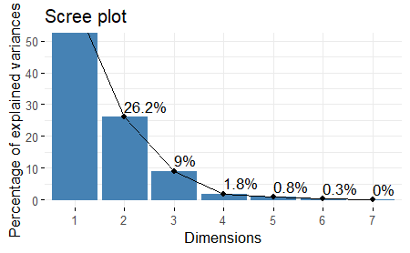

```r
library(factoextra)
# Visualisation des valeurs propres pour savoir combien de composantes à retenir
fviz_eig(res_pca, addlabels = TRUE, ylim = c(0, 50))
```

- On a 2 dimennsions qui sont superieur à 20%.

## Intérpretation des varibles

```r
res_pca$var$contrib
```

```
             Dim.1      Dim.2       Dim.3       Dim.4      Dim.5
pain      5.728347 38.7099457  0.01173363 29.65422814  0.1729896
légumes  21.701142  0.9742516  0.37861862  0.06705758 65.5409660
fruits   19.928509  4.2043428  2.13682629 29.86106730  0.4388878
viande   21.357467  1.9822115  4.30870935  0.27877824 17.2275155
volaille 19.171881  3.8871549 12.57112952 10.38326989  4.8272188
lait      7.871705 27.3167578 19.67056395 20.43295794 11.3025663
vin       4.240950 22.9253357 60.92241863  9.32264091  0.4898559
```

```r
res_pca$var$coord
```

```
              Dim.1      Dim.2       Dim.3        Dim.4        Dim.5
pain      0.4982464  0.8418968 -0.00859835 -0.194874747  0.009955769
légumes   0.9697745  0.1335621 -0.04884272 -0.009266937 -0.193785469
fruits    0.9293234 -0.2774576  0.11603352  0.195553195 -0.015857750
viande    0.9620649 -0.1905121  0.16476784 -0.018894773  0.099351886
volaille  0.9115109 -0.2667863  0.28144012 -0.115313280  0.052591224
lait      0.5840686  0.7072324 -0.35205236  0.161762509  0.080473580
vin      -0.4287075  0.6478962  0.61956579  0.109265166 -0.016753246
```

```r
res_pca$var$cos2
```

```
             Dim.1      Dim.2        Dim.3        Dim.4        Dim.5
pain     0.2482495 0.70879028 7.393163e-05 3.797617e-02 9.911734e-05
légumes  0.9404627 0.01783883 2.385611e-03 8.587612e-05 3.755281e-02
fruits   0.8636421 0.07698273 1.346378e-02 3.824105e-02 2.514682e-04
viande   0.9255688 0.03629486 2.714844e-02 3.570125e-04 9.870797e-03
volaille 0.8308521 0.07117493 7.920854e-02 1.329715e-02 2.765837e-03
lait     0.3411362 0.50017772 1.239409e-01 2.616711e-02 6.475997e-03
vin      0.1837901 0.41976952 3.838618e-01 1.193888e-02 2.806713e-04
```

## Graphe des variables

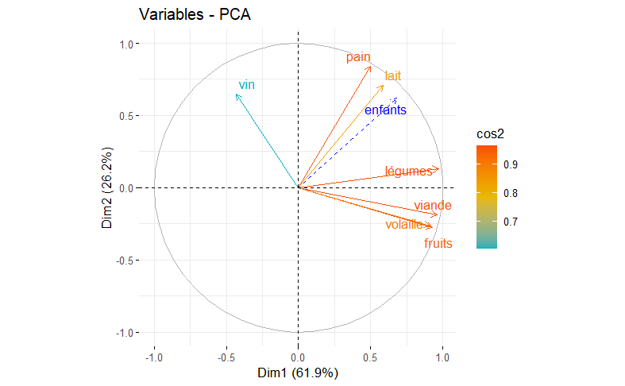

```r
fviz_pca_var(res_pca, col.var = "cos2" , gradient.cols = c("#00AFBB", "#E7B800", "#FC4E07") , repel = TRUE)
```

## Intérpretation des individus

```r
res_pca$ind$contrib
```

```
         Dim.1       Dim.2      Dim.3      Dim.4       Dim.5
1  17.17992432  0.65520928  2.3197815  9.4020546  7.92045734
2   7.50446660 15.92785385 24.7325836  1.7746889  1.38771500
3   0.02941549  2.61476650 29.1449023  2.6758596 31.46221747
4   8.76370998  0.52126301  0.1701265  0.7940656  0.01427883
5   5.91769807  0.14288107  3.6205860  1.5245443  4.55623239
6   6.02955914  9.11516081 14.2836690 13.1927666  0.81319387
7   1.83709780  9.35235997  1.1115562  4.8553848  1.38799326
8   0.13549308  1.99006070  1.0696570  5.9119004  4.01462965
9   5.38240368 14.96348006  0.1374591 11.3050038 28.21995663
10  0.09988375 38.29939283  4.6296921  4.2810979  2.40495759
11  7.97596220  6.36901975 14.1338616  7.4486637 16.90398270
12 39.14438589  0.04855217  4.6461252 36.8339698  0.91438527
```

```r
res_pca$ind$coord
```

```
        Dim.1      Dim.2      Dim.3      Dim.4       Dim.5
1  -2.9890332 -0.3794270  0.4188061  0.3801143  0.23336222
2  -1.9755136 -1.8707547 -1.3674902 -0.1651445 -0.09767998
3  -0.1236825 -0.7579746  1.4844678  0.2027844 -0.46510400
4  -2.1348340  0.3384283 -0.1134163  0.1104666  0.00990836
5  -1.7542703 -0.1771844 -0.5232135  0.1530639 -0.17699392
6   1.7707730 -1.4152084  1.0392245 -0.4502677 -0.07477432
7  -0.9774313  1.4335037 -0.2899047 -0.2731585  0.09768977
8  -0.2654475  0.6612587  0.2843883  0.3014161  0.16614151
9   1.6730474 -1.8132368  0.1019474 -0.4168101  0.44048749
10  0.2279122  2.9009094  0.5916509 -0.2564959  0.12859057
11  2.0366278  1.1829721 -1.0337604 -0.3383312 -0.34091800
12  4.5118521 -0.1032863 -0.5927000  0.7523625  0.07929029
```

```r
res_pca$ind$cos2
```

```
         Dim.1        Dim.2       Dim.3       Dim.4        Dim.5
1  0.944642936 0.0152216836 0.018545231 0.015276882 5.757942e-03
2  0.418914067 0.3756631442 0.200730487 0.002927473 1.024179e-03
3  0.004972127 0.1867390691 0.716254571 0.013365798 7.031144e-02
4  0.968255034 0.0243329568 0.002732828 0.002592529 2.085764e-05
5  0.894091611 0.0091209513 0.079532902 0.006806672 9.101347e-03
6  0.482017610 0.3078774588 0.166018261 0.031165834 8.594924e-04
7  0.299834570 0.6449214960 0.026376646 0.023417396 2.995073e-03
8  0.097855549 0.6072546752 0.112318579 0.126171413 3.833402e-02
9  0.429334709 0.5042995205 0.001594160 0.026647469 2.976094e-02
10 0.005833452 0.9450589212 0.039311683 0.007388418 1.856987e-03
11 0.604321225 0.2038888935 0.155698465 0.016677412 1.693341e-02
12 0.955671072 0.0005008225 0.016491821 0.026573760 2.951473e-04
```

## Graphe des individus

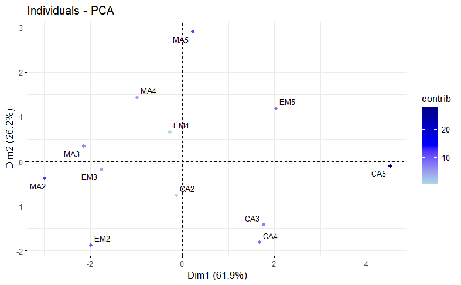

```r
library(factoextra)
library(ggrepel)

# Créer un data frame avec les coordonnées des individus
ind_coord <- as.data.frame(res_pca$ind$coord)

# Ajouter l'identifiant IDEN à chaque individu
ind_coord$IDEN <- df$IDEN  # <-- Attention à la casse : 'NewData' et pas 'Newdata'

# Visualiser l'ACP avec couleurs selon la contribution
p <- fviz_pca_ind(res_pca,
                  col.ind = "contrib",
                  gradient.cols = c("lightblue", "blue", "darkblue"),
                  geom = "point",
                  label = "none",
                  repel = TRUE)

# Ajouter les étiquettes avec les IDEN
p + geom_text_repel(data = ind_coord,
                    aes(x = Dim.1, y = Dim.2, label = IDEN),
                    size = 3)
```

Chaque point bleu représente un individu et plus ils sont proches, plus leurs comportements sont similaires. ** Par exemple, CA5 est très différent de EM2, tandis que MA3, MA2 et EM3 partagent des comportements similaires. ** Les points bleus foncés indiquent les individus les plus influents dans l’analyse, comme CA5, EM2 et MA5, tandis que les points moins bleus (CA2, EM4) sont moins importants.

## Classification des individus en fonction des composantes principales

```r
 set.seed(123)  # pour la reproductibilité

# Appliquer K-means sur les deux premières dimensions de l'ACP
km_res <- kmeans(res_pca$ind$coord[, 1:2], centers = 3, nstart = 25)

# Ajouter les clusters à la table des individus
ind_coord$cluster <- as.factor(km_res$cluster)
```

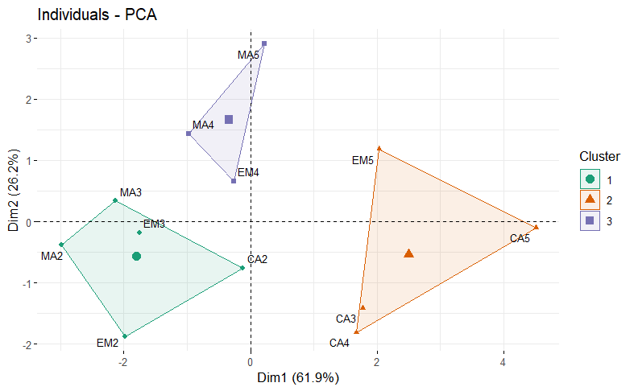

```r
# Visualisation avec coloration par cluster
p <- fviz_pca_ind(res_pca,
                  geom = "point",
                  label = "none",
                  col.ind = ind_coord$cluster, # colorer selon cluster
                  palette = "Dark2",
                  addEllipses = TRUE,
                  ellipse.type = "convex",
                  legend.title = "Cluster")

# Ajouter les labels IDEN
p + geom_text_repel(data = ind_coord,
                    aes(x = Dim.1, y = Dim.2, label = IDEN),
                    size = 3)
```

### Visualisation des individus

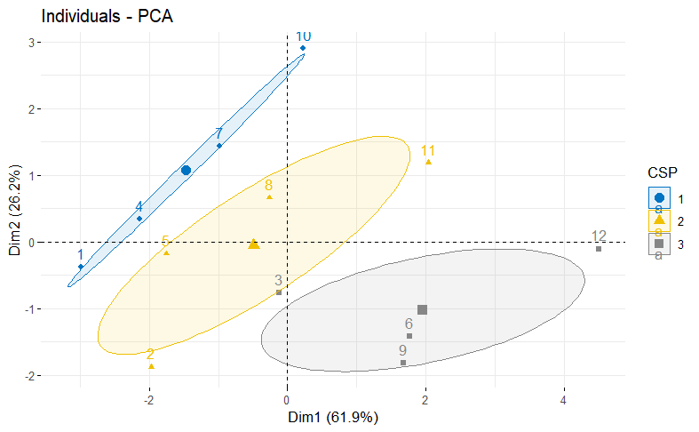

```r
# Visualisation des individus sur le plan principal
fviz_pca_ind(res_pca, col.ind = csp, # Colorer les points par CSP
             palette = "jco",
             addEllipses = TRUE,
             ellipse.type = "confidence",
             legend.title = "CSP")
```

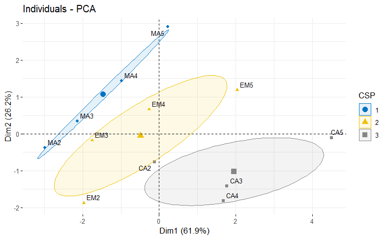

```r
library(factoextra)
library(ggrepel)

# Extraire les coordonnées des individus
ind_coord <- as.data.frame(res_pca$ind$coord)
ind_coord$IDEN <- df$IDEN
ind_coord$CSP <- df$CSP

# Visualisation personnalisée des individus
p <- fviz_pca_ind(res_pca,
                  label = "none",            # on ajoutera les labels manuellement
                  habillage = "CSP",         # colorer selon CSP
                  palette = "jco",           # palette de couleurs
                  addEllipses = TRUE,        # ajouter les ellipses par groupe
                  ellipse.type = "confidence",
                  repel = TRUE,
                  legend.title = "CSP")

# Ajouter les noms des individus (IDEN)
p + geom_text_repel(data = ind_coord,
                    aes(x = Dim.1, y = Dim.2, label = IDEN),
                    size = 3)
```

### Graphe des variables et des individus

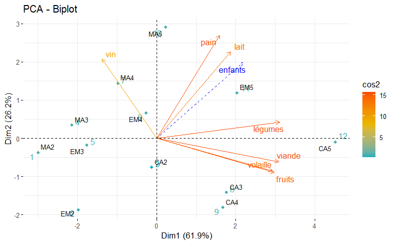

```r
library(factoextra)
library(ggrepel)

# Créer un data frame avec les coordonnées des individus
ind_coord <- as.data.frame(res_pca$ind$coord)
ind_coord$IDEN <- df$IDEN  # Associer les IDEN

# Créer le biplot avec coloration des individus et des variables
p <- fviz_pca_biplot(res_pca,
                     col.ind = "cos2",    # couleur selon la qualité de représentation
                     col.var = "contrib", # couleur des variables selon leur contribution
                     gradient.cols = c("#00AFBB", "#E7B800", "#FC4E07"),
                     repel = TRUE)


# Ajouter les étiquettes avec les IDEN
p + geom_text_repel(data = ind_coord,
                    aes(x = Dim.1, y = Dim.2, label = IDEN),
                    size = 3)
```

- Les flèches proches les unes des autres (comme fruits, viande, légumes, volaille) indiquent des produits consommés ensemble, souvent par les mêmes profils (CA3, CA4, CA5).
- Les groupes proches d’une flèche sont influencés par la variable correspondante.
- Ainsi, EM5 se trouve proche des flèches lait et enfants, traduisant une consommation importante de ces produits, potentiellement liée à la présence d’enfants dans le foyer.

# 7. Conclusion

Cette ACP a permis de :

- Réduire la complexité des données sans perte majeure d’information.
- Détecter des regroupements d’individus selon leurs profils de consommation.
- Comprendre les influences de certaines variables (ex. CSP) sur la consommation.